# Migration Experiment_01-Data-Exploration

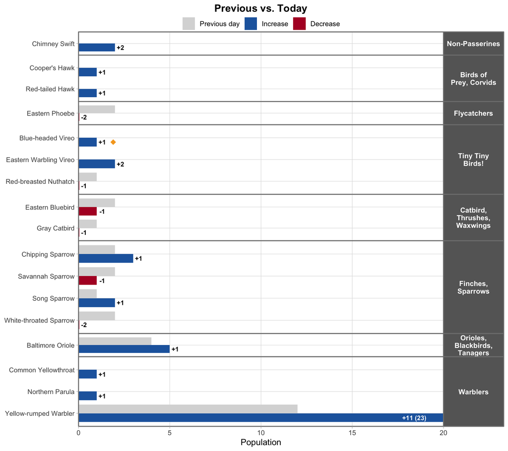

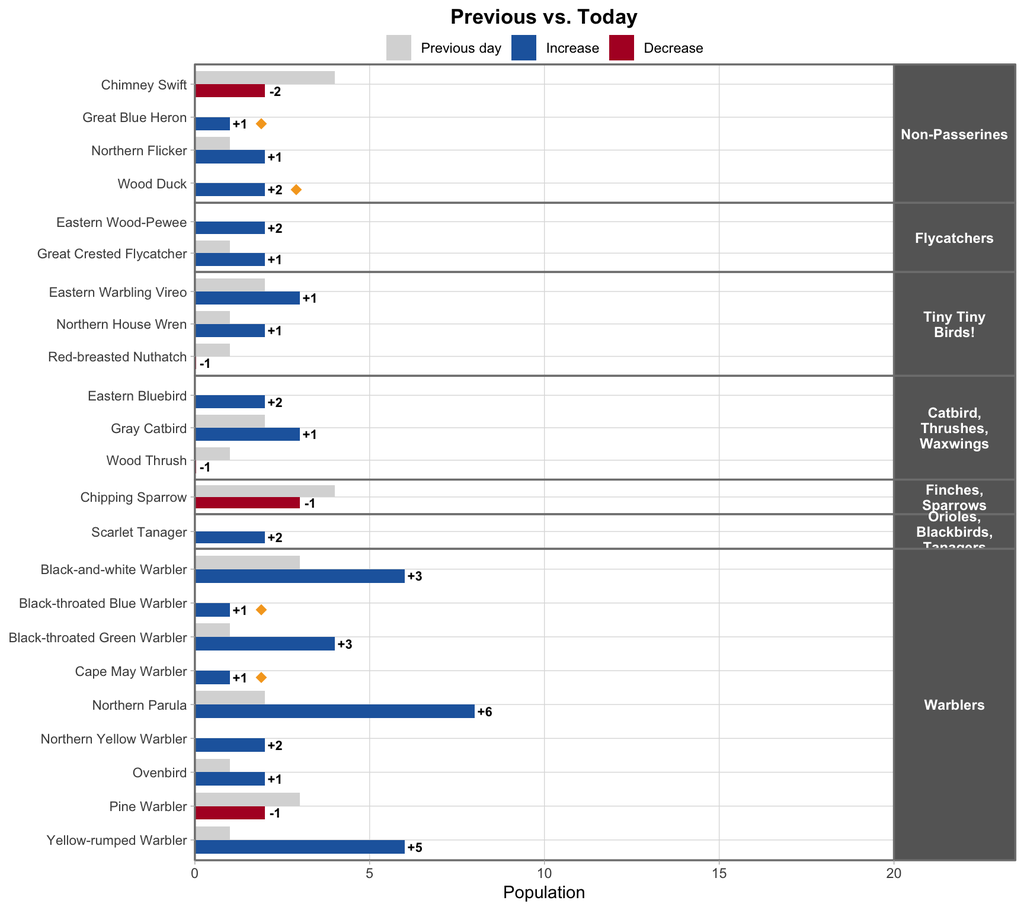

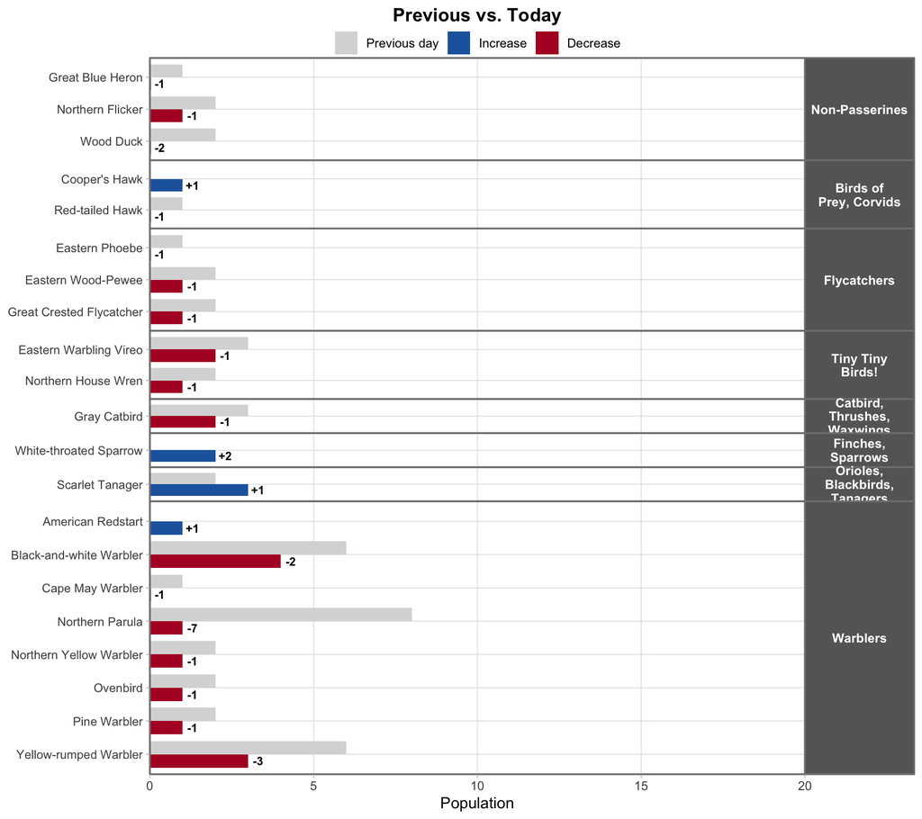

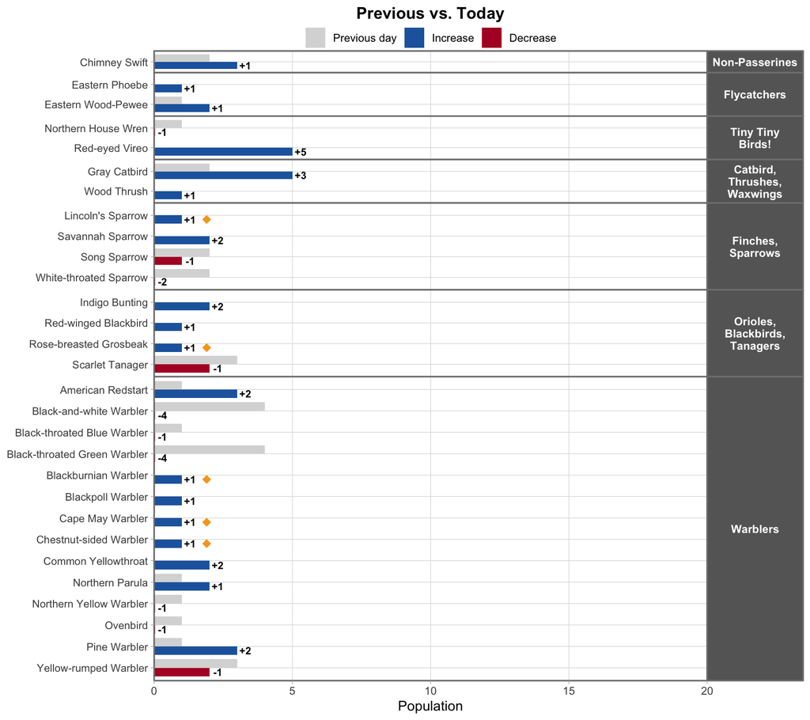

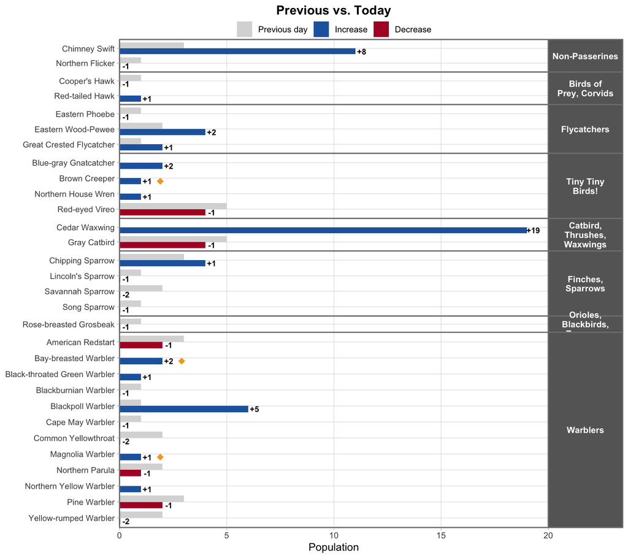

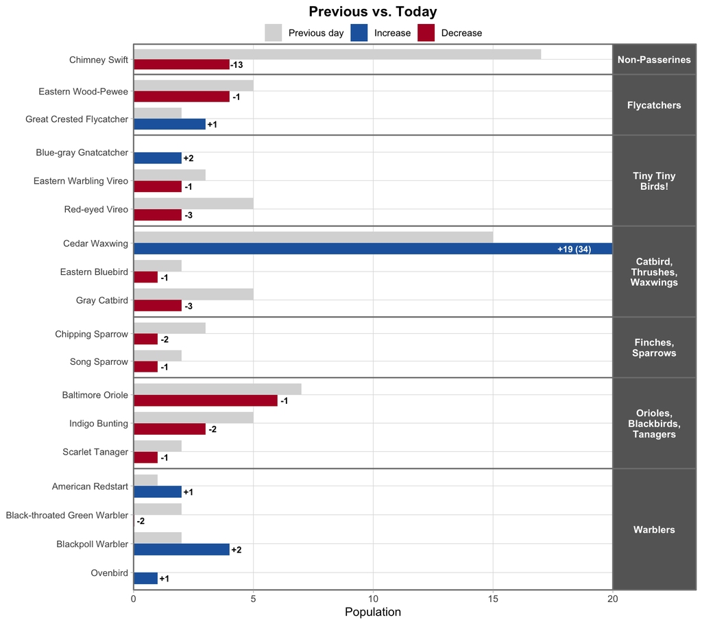

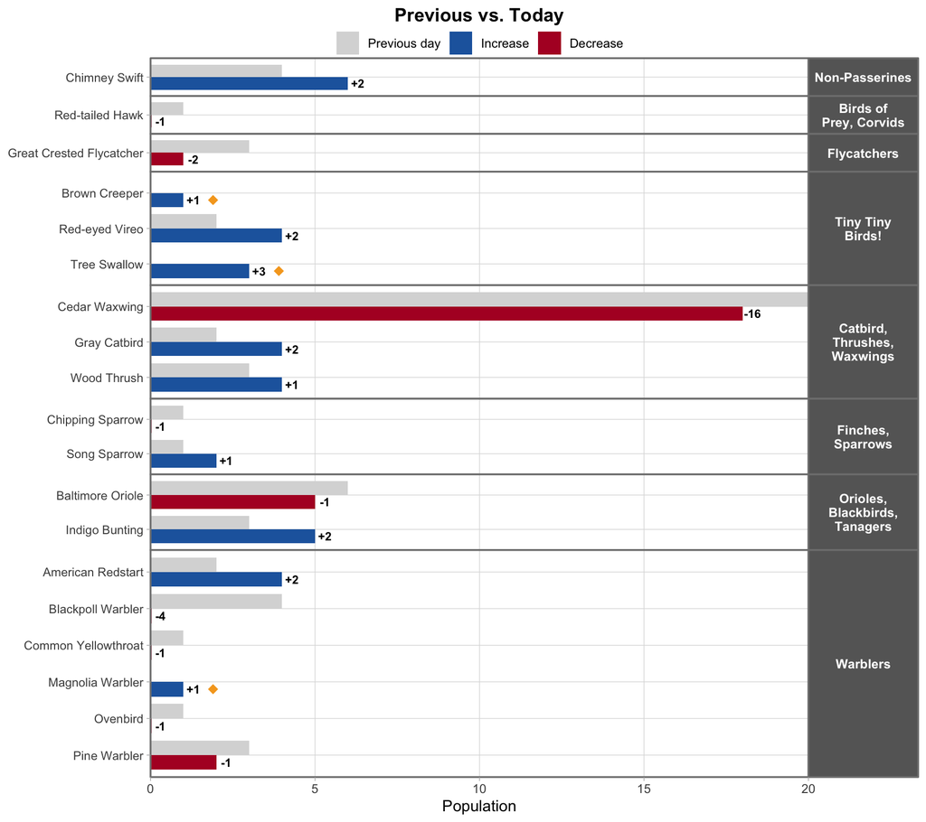

```r
# back near the original pre-grouping height (was 9) -- stacking every
# taxonomic group as its own bordered panel (ncol = 1) adds a strip header
# per group on top of the species rows, and that overhead (8 groups' worth
# of strips) plus the earlier +50% row-spacing request together pushed this
# to 18, then 13, and both were still too tall to see a whole chart without
# scrolling. Going back to ~8 means giving up most of that extra breathing
# room between species -- the boxed/grouped layout itself is kept, but rows
# are packed closer together again to fit on one screen. If species rows
# feel too cramped at this height, that's the actual trade-off to revisit
# (drop back to fewer/no groups, or accept more scrolling) rather than a
# number to keep nudging.
for (wave_name in wave_bounds$Wave) {
  for (d in obs_days_for_wave(wave_name)) {
    print(plot_day_grouped_horizontal(grid_favorites_nonresident_wave, wave_name, d,
                                       "Non-Resident Favorites",
                                       warbler_sp = warbler_sp_in_favorites_nonresident))
  }
}
```

```r
# one saved sample (Wave 1 / day 5) for the story site's "other styles"
# preview at the bottom of the wave page -- Style D isn't looped/saved for
# every wave/day like Style C is, just this single representative example
ggsave(file.path(fig_dir, "StyleD_sample.png"),
       plot_day_grouped_horizontal(grid_favorites_nonresident_wave, "Wave 1", 5,
                                    "Non-Resident Favorites",
                                    warbler_sp = warbler_sp_in_favorites_nonresident),
       width = 9, height = 8, dpi = 150)
```

### VI. E.3.b. Style B: Faceted by Taxonomic Group

Same Previous-vs-Today bars as Style D, but vertical and split into small panels by taxonomic group (`data/Taxonomy-ish_Groupings/species_groups_moderate.csv`) instead of one long row. Panel width scales with species count per group, so bar thickness stays consistent across panels – needs the `ggh4x` package (loaded in Setup).

```r
# taxon_groups / taxon_group_order / taxon_group_colors are defined once,
# above Style D, and shared by both styles.
plot_day_faceted_taxon <- function(df_wave, wave_name, day, warbler_sp = NULL) {
  df <- df_wave %>%
    filter(Wave == wave_name, Day == day, !is.na(Delta), Delta != 0) %>%
    mutate(Species = droplevels(Species),
           Is.Uncommon = Species %in% uncommon_sp,
           Prev = Population - Delta) %>%
    left_join(taxon_groups, by = "Species") %>%
    mutate(group_name = factor(group_name, levels = taxon_group_order))

  # label/diamond need to sit over the TODAY bar specifically -- both use
  # position_nudge(x = today_offset) to match the +0.2 dodge offset
  # position_dodge(width = 0.8) gives the 2nd ("Today") group.
  today_offset <- 0.2

  long <- df %>%
    transmute(Species, group_name, Delta, Previous = Prev, Today = Population) %>%
    pivot_longer(cols = c(Previous, Today), names_to = "When", values_to = "Count") %>%
    mutate(When = factor(When, levels = c("Previous", "Today")),
           bar_fill = case_when(
             When == "Previous" ~ "Previous",
             When == "Today" & Delta > 0 ~ "Increase",
             When == "Today" & Delta < 0 ~ "Decrease"))

  label_df <- df %>%
    mutate(label_text = ifelse(Delta > 0, paste0("+", Delta), as.character(Delta)),
           label_y = pmin(Population, count_ylim[2]) + 0.6)   # close to the bar

  diamond_df <- df %>% filter(Is.Uncommon, Population > 0) %>%
    mutate(diamond_y = pmin(Population, count_ylim[2]) + 1.5)  # above the label

  p <- ggplot(long, aes(x = Species, y = pmin(Count, count_ylim[2]), fill = bar_fill, group = When)) +
    geom_col(position = position_dodge(width = 0.8), width = 0.8) +
    geom_text(data = label_df, aes(x = Species, y = label_y, label = label_text),
              position = position_nudge(x = today_offset),
              inherit.aes = FALSE, size = 2.9, fontface = "bold") +
    geom_point(data = diamond_df, aes(x = Species, y = diamond_y),
               position = position_nudge(x = today_offset),
               inherit.aes = FALSE, shape = 18, size = 3, color = "#F5A623") +
    scale_fill_manual(values = c(Previous = "grey85", Increase = "#2166AC", Decrease = "#B2182B"),
                       breaks = c("Previous", "Increase", "Decrease"),
                       labels = c("Previous day", "Increase", "Decrease"), name = NULL) +
    scale_y_continuous(breaks = count_breaks, expand = expansion(mult = c(0, 0))) +
    coord_cartesian(ylim = count_ylim, clip = "off") +
    # label_wrap_gen() wraps each strip title onto ~2 lines instead of
    # running long names into the neighboring panel
    facet_wrap2(~group_name, scales = "free_x", nrow = 1,
                labeller = label_wrap_gen(width = 14)
                # one strip color per taxonomic group, matching the tree png --
                # too busy layered on top of the increase/decrease colors, so
                # back to plain grey for now. Re-enable by uncommenting:
                # , strip = strip_themed(background_x = elem_list_rect(
                #     fill = taxon_group_colors[levels(droplevels(df$group_name))]))
                ) +
    labs(title = "Previous vs. Today, grouped by taxonomy", x = NULL, y = "Population") +
    theme_light() +
    theme(plot.title    = element_text(hjust = 0.5, face = "bold", size = 13),
          legend.position = "top",
          strip.text    = element_text(face = "bold", size = 9, color = "white"),
          strip.background = element_rect(fill = "grey40", color = "grey50", linewidth = 0.6),
          # bordered strip + panel, so at panel.spacing = 0 you get one clean
          # dividing line between groups instead of everything visually
          # blurring together (which is what plain 0-spacing with no border did)
          panel.border  = element_rect(color = "grey50", fill = NA, linewidth = 0.6),
          axis.text.x   = element_text(angle = 40, hjust = 1, size = 8),
          panel.spacing = unit(0, "lines"),
          panel.grid.minor = element_blank())

  # panel width per group, proportional to species count, so bar thickness
  # stays consistent instead of a 1-species panel stretching its bar wide
  panel_species_n <- df %>% distinct(Species, group_name) %>% count(group_name) %>%
    arrange(match(group_name, levels(df$group_name))) %>% pull(n)
  p + force_panelsizes(cols = panel_species_n)
}
```

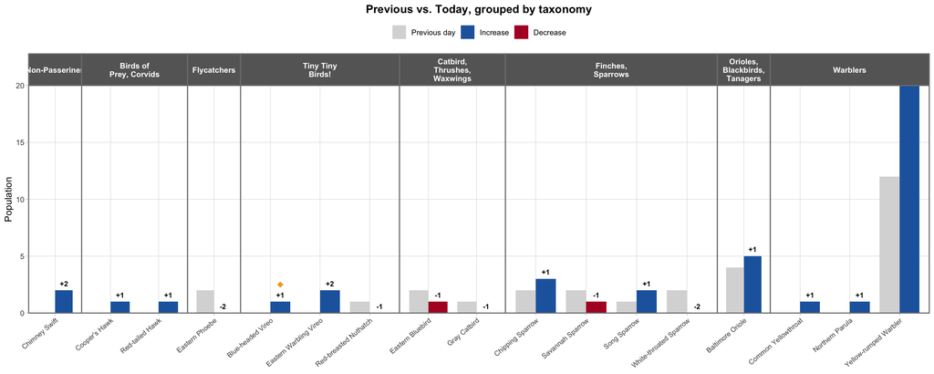

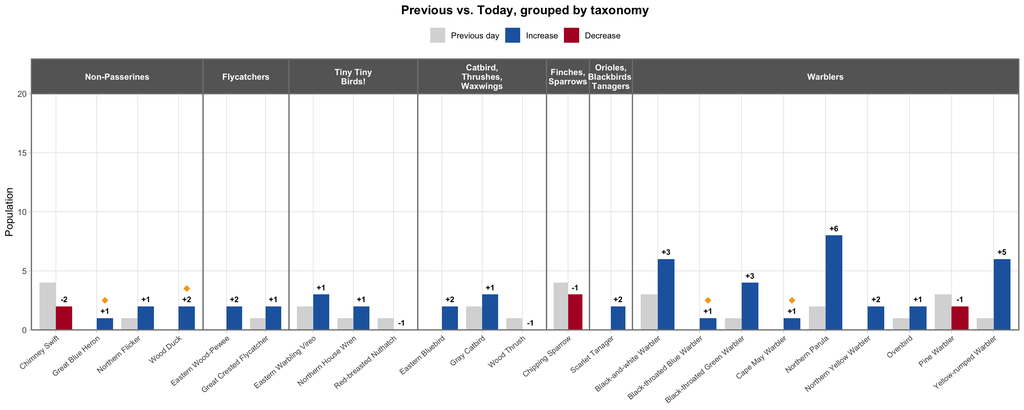

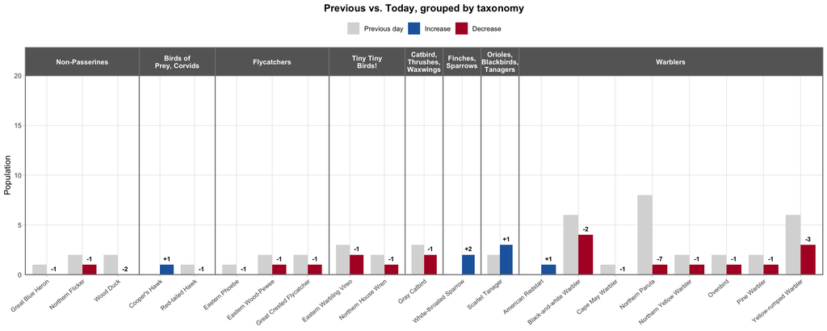

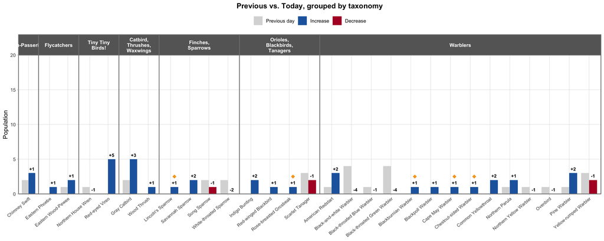

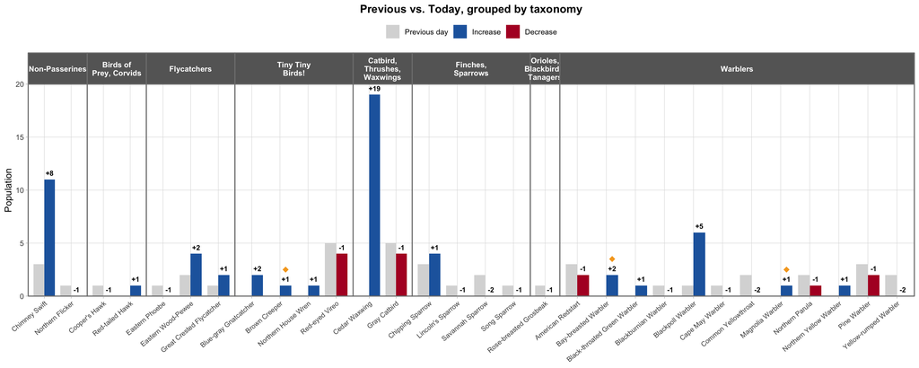

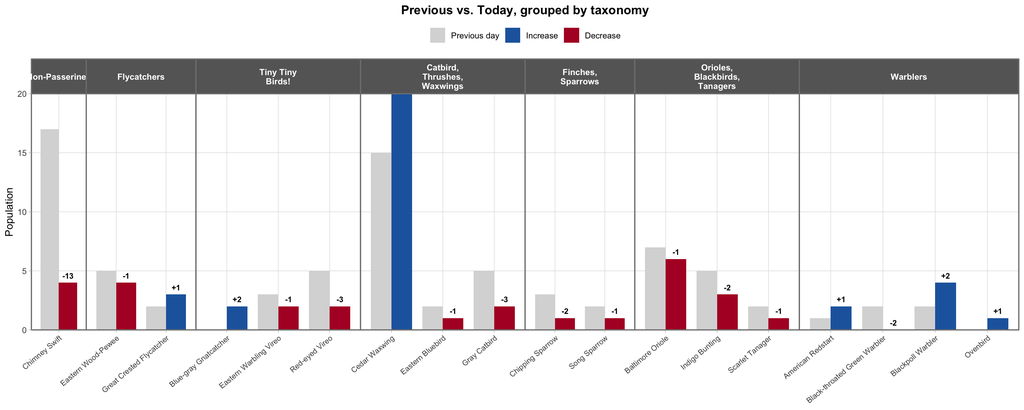

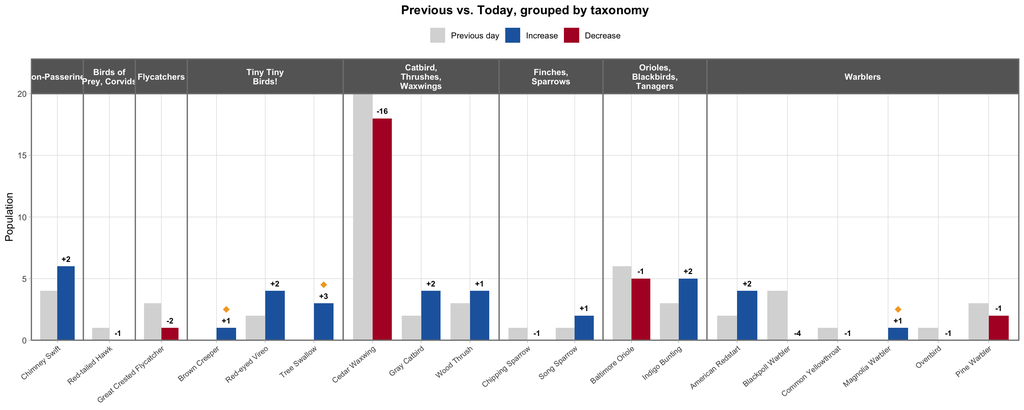

```r
for (wave_name in wave_bounds$Wave) {
  for (d in obs_days_for_wave(wave_name)) {
    print(plot_day_faceted_taxon(grid_favorites_nonresident_wave, wave_name, d,
                                  warbler_sp = warbler_sp_in_favorites_nonresident))
  }
}
```

```r
# one saved sample (Wave 1 / day 5) for the story site's "other styles"
# preview at the bottom of the wave page -- same idea as Style D's sample
ggsave(file.path(fig_dir, "StyleB_sample.png"),
       plot_day_faceted_taxon(grid_favorites_nonresident_wave, "Wave 1", 5,
                               warbler_sp = warbler_sp_in_favorites_nonresident),
       width = 15, height = 6, dpi = 150)
```

### VI. E.3.c. Style C: Overlapping Bars

A new, separate style rather than another rewrite of Style D – Style D has already been reworked heavily enough (rotated Style B, then retuned several times) that folding this in would blur two different ideas together.

Same taxonomy-grouped, boxed-panel layout as Style D (species on the y-axis, one bordered panel per taxonomic group, stacked in a column), but the bars themselves work differently: instead of two bars side by side (dodged), Previous and Today are drawn as ONE overlapping bar, anchored at 0 – never summed/stacked. Whichever day had the SMALLER count is drawn on top of the larger one, so it fully covers the shared portion; only the larger day’s excess peeks out beyond it. For an increase (Today > Previous), that means grey (Previous, smaller, drawn on top) covers the bar from 0 up to Previous, with blue showing from Previous to Today. For a decrease (Today < Previous), red (Today, smaller, drawn on top) covers 0 up to Today, with grey showing from Today to Previous.

```r
plot_day_overlapping_horizontal <- function(df_wave, wave_name, day, subset_label, warbler_sp = NULL) {
  df <- df_wave %>%
    filter(Wave == wave_name, Day == day, !is.na(Delta), Delta != 0) %>%
    mutate(Species = droplevels(Species),
           Is.Uncommon = Species %in% uncommon_sp,
           Prev = Population - Delta) %>%
    left_join(taxon_groups, by = "Species") %>%
    mutate(group_name = factor(group_name, levels = taxon_group_order))

  cap_off <- 1.6   # how far inside the frame edge a capped label/diamond sits

  # Independently pmin()-ing Previous and Today to the axis cap can make an
  # increase or decrease invisible: if BOTH exceed count_ylim[2], they both
  # clamp to the same drawn width and the smaller (front) bar covers the
  # larger one completely, erasing the one sliver of color this whole style
  # depends on. When capping would collide like that, the smaller-value bar
  # is nudged in from the cap by a hair so the larger one still peeks out.
  df <- df %>%
    mutate(Today_draw    = pmin(Population, count_ylim[2]),
           Previous_draw = pmin(Prev, count_ylim[2]),
           Today_draw    = ifelse(Delta < 0 & Today_draw >= Previous_draw,
                                   pmax(Previous_draw - 0.3, 0), Today_draw),
           Previous_draw = ifelse(Delta > 0 & Previous_draw >= Today_draw,
                                   pmax(Today_draw - 0.3, 0), Previous_draw))

  # geom_col (position = "identity", no dodge) draws rows in data order,
  # later rows on top of earlier ones -- arranging each species' pair with
  # the LARGER count first and the SMALLER count second is what makes the
  # smaller bar visually cover the larger one instead of the two just
  # summing/stacking. No today_offset/half_gap nudging needed anywhere
  # below, unlike Style D -- there's only one bar per species now, not two
  # dodged lanes, so labels and diamonds sit at the plain Species position.
  long <- df %>%
    transmute(Species, group_name, Delta, Previous = Prev, Today = Population,
              Previous_draw, Today_draw) %>%
    pivot_longer(cols = c(Previous, Today), names_to = "When", values_to = "Count") %>%
    mutate(bar_fill = case_when(
             When == "Previous" ~ "Previous",
             When == "Today" & Delta > 0 ~ "Increase",
             When == "Today" & Delta < 0 ~ "Decrease"),
           x_draw = ifelse(When == "Today", Today_draw, Previous_draw),
           # a Today count of 0 draws as literally nothing with geom_col --
           # give it a hairline right at the axis (see Style D) so a species
           # that dropped to zero reads as "bottomed out", not blank space
           x_draw = ifelse(When == "Today" & Count == 0, 0.04, x_draw)) %>%
    arrange(Species, desc(Count))

  label_df <- df %>%
    mutate(Capped = Population >= count_ylim[2],
           label_text = ifelse(Delta > 0, paste0("+", Delta), as.character(Delta)),
           # a capped bar's tip is off the visible axis, so the label can't
           # sit past it the normal way -- it drops onto/inside the bar
           # itself, near its (invisible) tip, with the true count added on
           label_text = ifelse(Capped, paste0(label_text, " (", Population, ")"), label_text),
           label_x = ifelse(Capped, count_ylim[2] - cap_off, pmin(Population, count_ylim[2]) + 0.3),
           label_col = ifelse(Capped, "white", "black"))

  diamond_df <- df %>% filter(Is.Uncommon, Population > 0) %>%
    mutate(diamond_x = ifelse(Population >= count_ylim[2], count_ylim[2] - (cap_off + 1.1),
                              pmin(Population, count_ylim[2]) + 0.9))  # just beyond the label

  p <- ggplot(long, aes(y = Species, x = x_draw, fill = bar_fill)) +
    geom_col(position = "identity", width = 0.65) +
    geom_text(data = label_df, aes(y = Species, x = label_x, label = label_text, color = label_col),
              inherit.aes = FALSE, size = 2.9, fontface = "bold", show.legend = FALSE) +
    scale_color_identity() +
    geom_point(data = diamond_df, aes(y = Species, x = diamond_x),
               inherit.aes = FALSE, shape = 18, size = 3, color = "#F5A623") +
    scale_fill_manual(values = c(Previous = "grey85", Increase = "#2166AC", Decrease = "#B2182B"),
                       breaks = c("Previous", "Increase", "Decrease"),
                       labels = c("Previous day", "Increase", "Decrease"), name = NULL) +
    # first-listed species (top of each group in the CSV/tree order) reads
    # at the TOP of its panel -- ggplot's default discrete order is bottom-up
    scale_y_discrete(limits = rev) +
    scale_x_continuous(breaks = count_breaks, expand = expansion(mult = c(0, 0))) +
    coord_cartesian(xlim = count_ylim, clip = "off") +
    facet_wrap2(~group_name, scales = "free_y", ncol = 1, strip.position = "right",
                labeller = label_wrap_gen(width = 14)) +
    labs(title = "Previous vs. Today (overlapping)", x = "Population", y = NULL) +
    theme_light() +
    theme(plot.title    = element_text(hjust = 0.5, face = "bold", size = 13, margin = margin(b = 4)),
          legend.position = "top",
          legend.margin   = margin(t = 0, b = 0),
          legend.box.spacing = unit(2, "pt"),
          strip.text.y  = element_text(face = "bold", size = 9, color = "white", angle = 0),
          strip.background = element_rect(fill = "grey40", color = "grey50", linewidth = 0.6),
          panel.border  = element_rect(color = "grey50", fill = NA, linewidth = 0.6),
          axis.text.y   = element_text(size = 8.5),
          panel.spacing = unit(0, "lines"),
          panel.grid.minor = element_blank())

  panel_species_n <- df %>% distinct(Species, group_name) %>% count(group_name) %>%
    arrange(match(group_name, levels(df$group_name))) %>% pull(n)
  p + force_panelsizes(rows = panel_species_n)
}
```

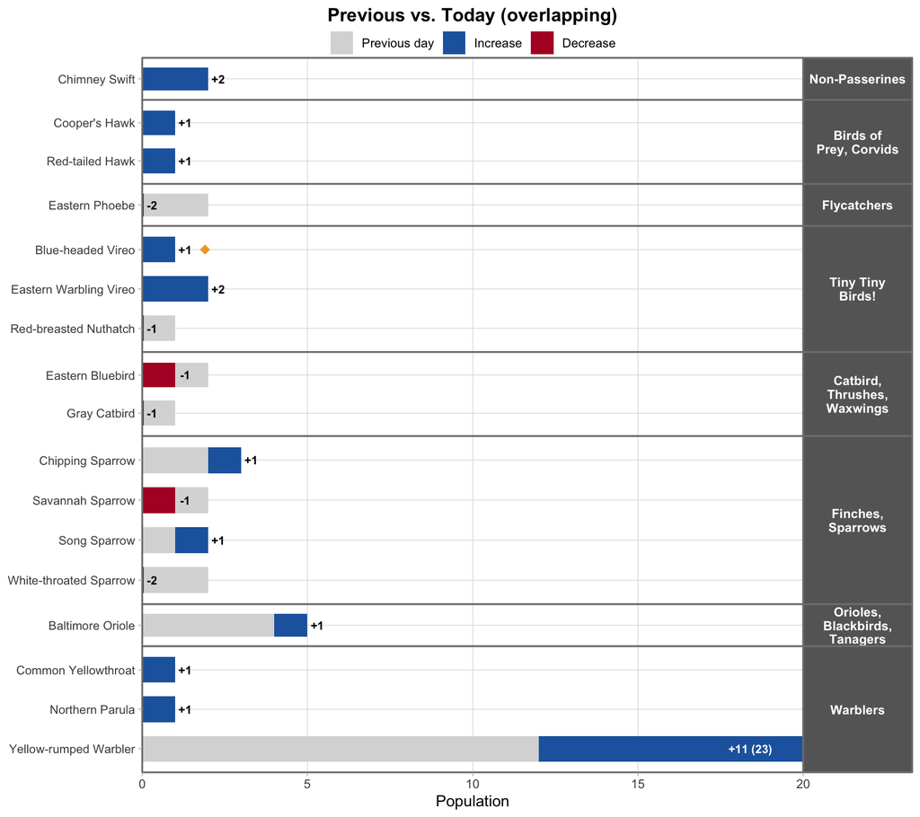

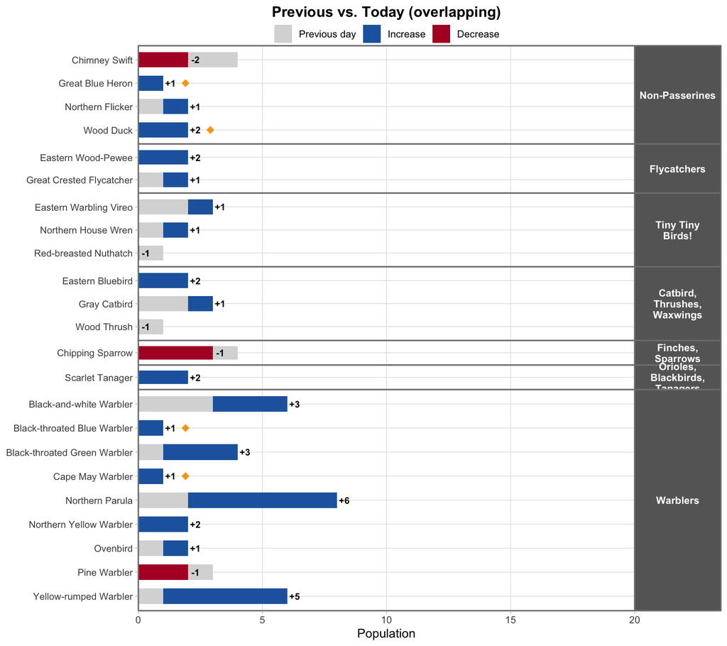

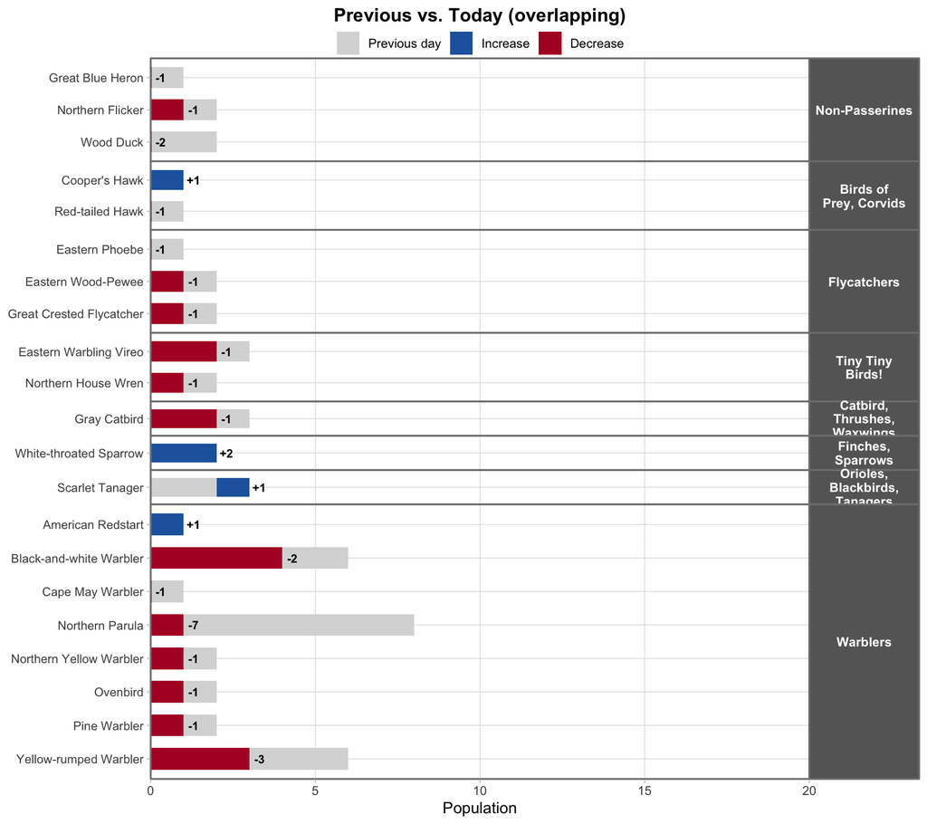

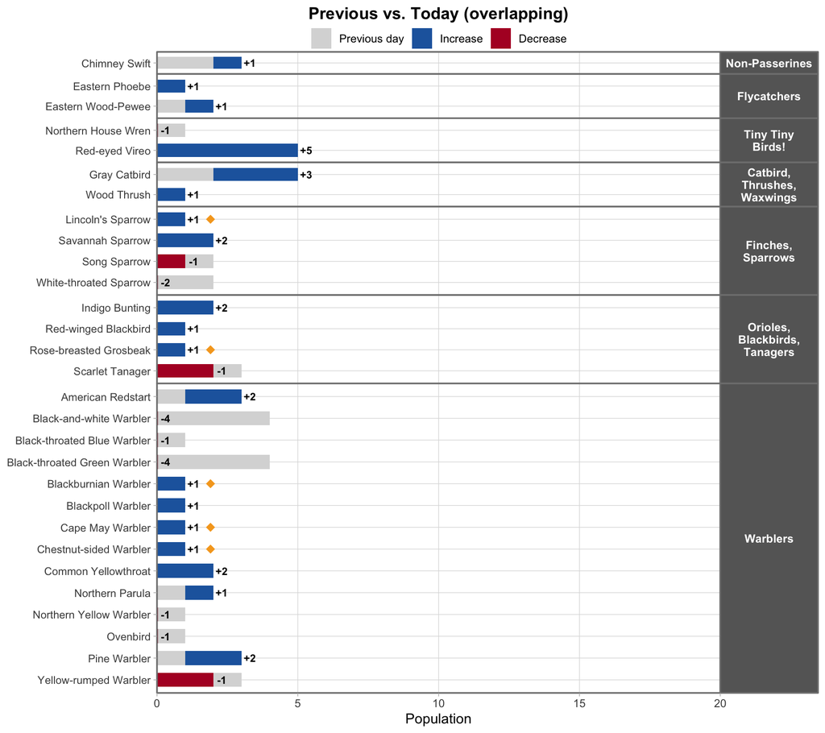

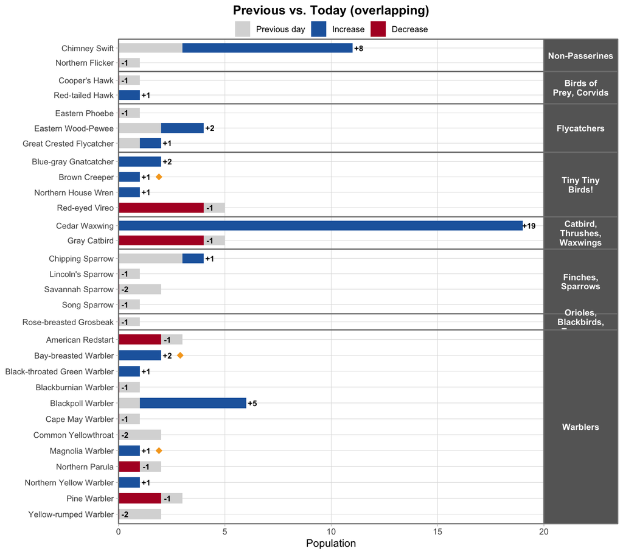

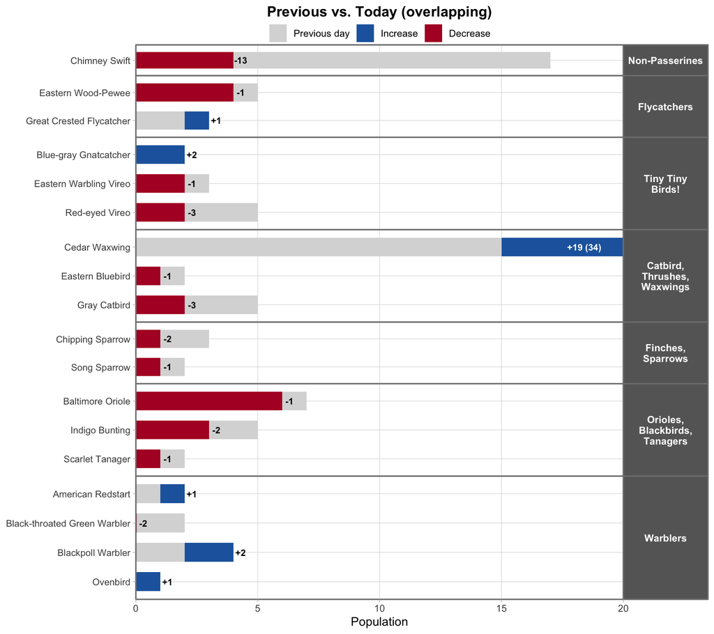

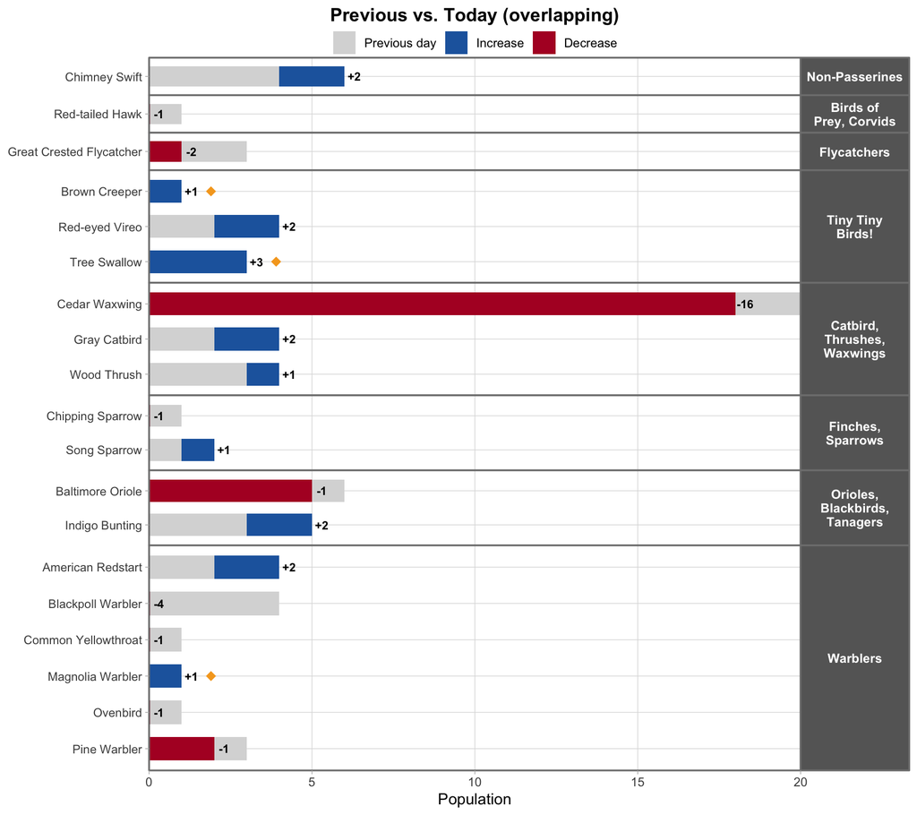

```r
# saves one PNG per wave/day, like VI.E.2's loop does -- these are the
# images the story site's wave page uses for its Style C figures
for (wave_name in wave_bounds$Wave) {
  for (d in obs_days_for_wave(wave_name)) {
    p <- plot_day_overlapping_horizontal(grid_favorites_nonresident_wave, wave_name, d,
                                          "Non-Resident Favorites",
                                          warbler_sp = warbler_sp_in_favorites_nonresident)
    print(p)
    ggsave(file.path(fig_dir, sprintf("%s_day%02d_stylec.png", gsub(" ", "", wave_name), d)),
           p, width = 9, height = 8, dpi = 150)
  }
}
```